# Practical Machine Learning Project

Joseph Swaminathan

December 27, 2015

## Executive Summary

Using devices such as Jawbone Up, Nike FuelBand, and Fitbit it is now possible to collect a large amount of data about personal activity relatively inexpensively. These type of devices are part of the quantified self movement - a group of enthusiasts who take measurements about themselves regularly to improve their health, to find patterns in their behavior, or because they are tech geeks. One thing that people regularly do is quantify how much of a particular activity they do, but they rarely quantify how well they do it.

The goal of this project is to predict the manner in which they did the exercise. This is the “classe” variable in the training set.

## Data Processing

### Load the data

The training data for this project are available here:

https://d396qusza40orc.cloudfront.net/predmachlearn/pml-training.csv

The test data are available here:

https://d396qusza40orc.cloudfront.net/predmachlearn/pml-testing.csv

```r
library(utils)
fileurl <- "https://d396qusza40orc.cloudfront.net/predmachlearn/pml-training.csv"
download.file(fileurl, destfile = "pml-training.csv")
fileurl <- "https://d396qusza40orc.cloudfront.net/predmachlearn/pml-testing.csv"
download.file(fileurl, destfile = "pml-testing.csv")

trainset <- read.csv("pml-training.csv", header=TRUE, sep=",", na.strings=c("NA",""))
testset <- read.csv("pml-testing.csv", header=TRUE, sep=",", na.strings=c("NA",""))
```

### Clean up the data

Remove the ID column (X)

```r
trainData <- subset(trainset, TRUE, select = -X)
testData <- subset(testset, TRUE, select = -X)
```

### Partition the data given for training into training & validation

```r
library(caret)
subTrainPart = createDataPartition(y=trainData$classe, p=0.6, list=FALSE)
training = trainData[subTrainPart,]
validation = trainData[-subTrainPart,]
```

### Remove columns that has too many NAs

```r
retain <- colSums(!is.na(training[,-ncol(training)]))/nrow(training) >= 0.6
training <- training[, retain]
testData <- testData[, retain]
```

## Choose a Model

Will choose a model that provides accuracy greater than 95%

As a first choice try Random Forest Model.

```r
library(randomForest)
set.seed(12345)

model <- randomForest(classe~.,data=training)
```

## Validate the Model

Print the model and check the Accuracy.

```r
print(model)
```

```
##
## Call:
##  randomForest(formula = classe ~ ., data = training)
##                Type of random forest: classification
##                      Number of trees: 500
## No. of variables tried at each split: 7
##
##         OOB estimate of  error rate: 0.18%
## Confusion matrix:
##      A    B    C    D    E  class.error
## A 3347    1    0    0    0 0.0002986858
## B    2 2277    0    0    0 0.0008775779
## C    0    5 2046    3    0 0.0038948393
## D    0    0    3 1927    0 0.0015544041
## E    0    0    0    7 2158 0.0032332564
```

The accuracy is 99.9 %

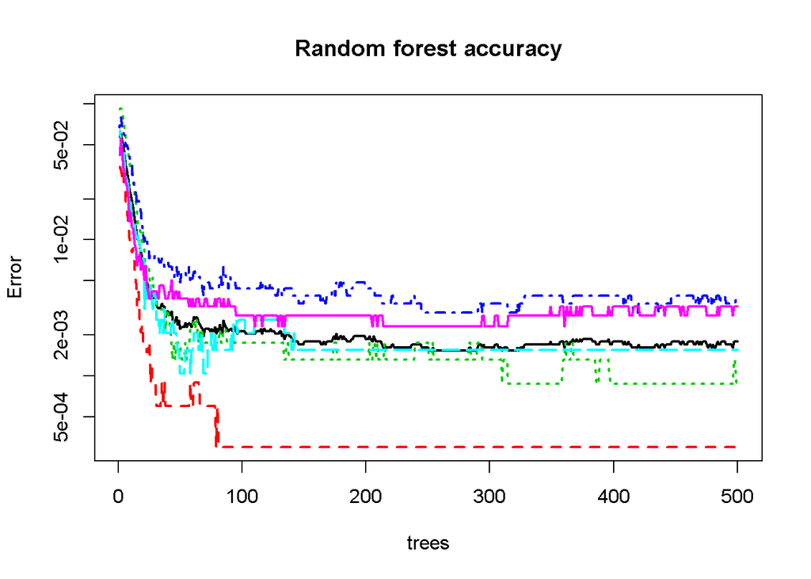

```r
plot(model, log ="y", lwd = 2, main = "Random forest accuracy")
```

Use Confusion Matrix to see how good the predictions are using the validation set

```r
confusionMatrix(predict(model,newdata=subset(validation, TRUE, select = -classe)),validation$classe)
```

```
## Confusion Matrix and Statistics
##
##           Reference
## Prediction    A    B    C    D    E
##          A 2230    0    0    0    0
##          B    2 1518    3    0    0
##          C    0    0 1365    1    0
##          D    0    0    0 1285    0
##          E    0    0    0    0 1442
##
## Overall Statistics
##
##                Accuracy : 0.9992
##                  95% CI : (0.9983, 0.9997)
##     No Information Rate : 0.2845
##     P-Value [Acc > NIR] : < 2.2e-16
##
##                   Kappa : 0.999
##  Mcnemar's Test P-Value : NA
##
## Statistics by Class:
##
##                      Class: A Class: B Class: C Class: D Class: E
## Sensitivity            0.9991   1.0000   0.9978   0.9992   1.0000
## Specificity            1.0000   0.9992   0.9998   1.0000   1.0000
## Pos Pred Value         1.0000   0.9967   0.9993   1.0000   1.0000
## Neg Pred Value         0.9996   1.0000   0.9995   0.9998   1.0000
## Prevalence             0.2845   0.1935   0.1744   0.1639   0.1838
## Detection Rate         0.2842   0.1935   0.1740   0.1638   0.1838
## Detection Prevalence   0.2842   0.1941   0.1741   0.1638   0.1838
## Balanced Accuracy      0.9996   0.9996   0.9988   0.9996   1.0000
```

Looking at the confusion matrix output we see there are very less errors (possitive number outside of the diagonal). The model seems to be holding good.

## Test the model against test data

Using a portion of training data for validation we find the model is able predict closely the outcome. Now we will use the test data to verify if this model holds good

```r
# Coerce testing dataset to same class and strucuture of training dataset
testData <- rbind(training[100, -ncol(training)] , testData[, -ncol(testData)])
row.names(testData) <- c(100, 1:20)

# Predict
predictions <- predict(model,newdata=testData[-1,])
print(predictions)
```

```
##  1  2  3  4  5  6  7  8  9 10 11 12 13 14 15 16 17 18 19 20
##  B  A  B  A  A  E  D  B  A  A  B  C  B  A  E  E  A  B  B  B
## Levels: A B C D E
```